# ExploreAndSummarize

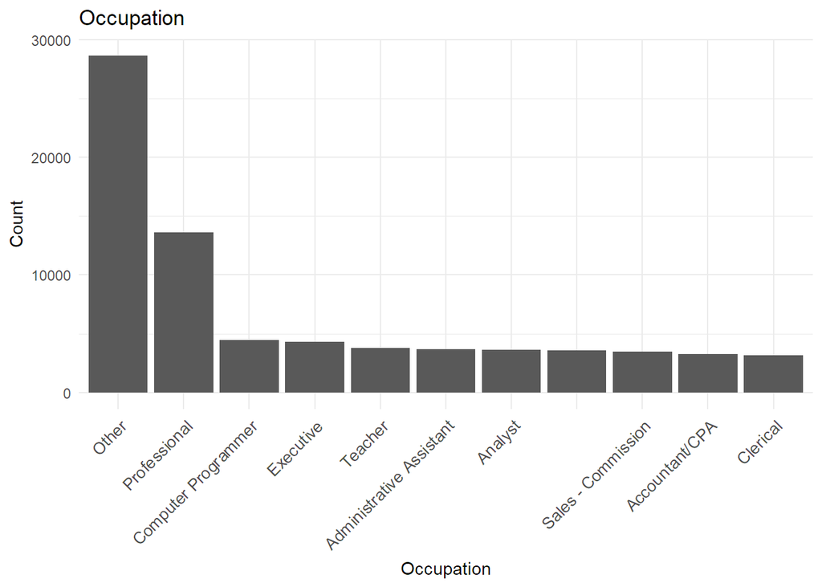

```r
RawData %>%
  count(Occupation) %>%
  filter(n > quantile(n,0.85)) %>%
  ggplot(aes(x = reorder(Occupation,-n), y = n)) +
    geom_bar(stat = "identity") + theme_minimal() +
    theme(axis.text.x = element_text(size = 10, angle= 45, hjust=1))+
    labs(title="Occupation ", x="Occupation", y="Count")
```

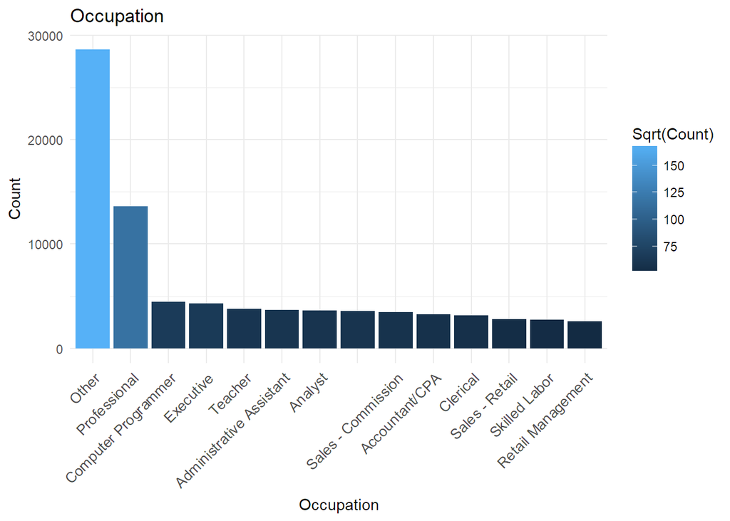

```r
RawData %>% count(Occupation) %>%
  mutate(Occupation=reorder(Occupation,-n))%>%
  filter(n>quantile(n,0.80))%>%
  ggplot(aes(Occupation, y = n,fill=sqrt(n)))+
    geom_bar(stat = "identity")+
    theme_minimal()+
    theme(axis.text.x = element_text(size = 10, angle= 45, hjust=1))+
  labs(title="Occupation ", x="Occupation", y="Count",fill="Sqrt(Count)")
```

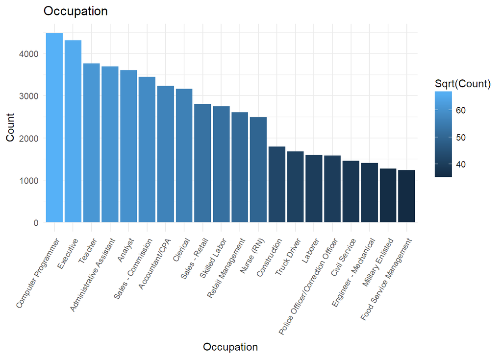

```r
RawData %>%
  filter(Occupation!="Other" )%>%
  filter(Occupation!="Professional" )%>%
  filter(Occupation!="")%>%
  count(Occupation) %>%
  mutate(Occupation=reorder(Occupation,-n))%>%
  filter(n>quantile(n,0.70))%>%
  ggplot(aes(x=Occupation, y = n,fill=sqrt(n)))+
    geom_bar(stat = "identity")+
    #scale_fill_viridis(option = "D")+
    theme_minimal()+
    theme(axis.text.x = element_text(size = 8, angle= 60, hjust=1))+
    labs(title="Occupation ", x="Occupation", y="Count",fill="Sqrt(Count)")
```

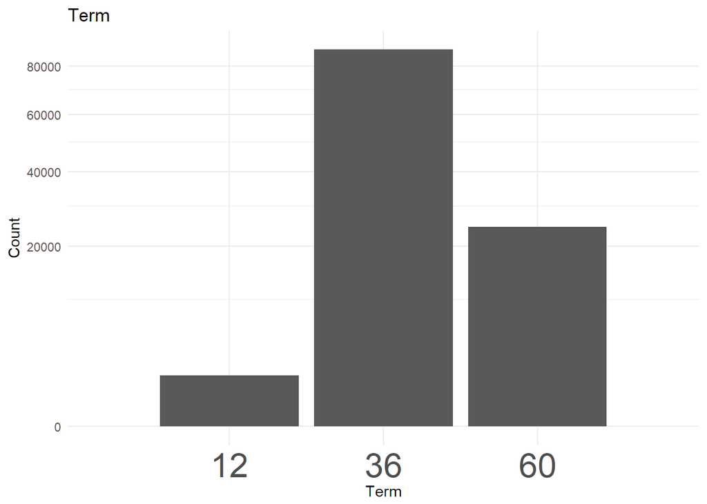

```r
RawData %>%
  #mutate(as.factor(Term))%>%
  #count(Term) %>%
  ggplot(aes(x=as.factor(Term)))+
    geom_bar()+
    coord_trans(y='sqrt')+
    theme_minimal()+
    theme(axis.text.x = element_text(size = 24))+
    labs(title="Term", x="Term", y="Count")
```

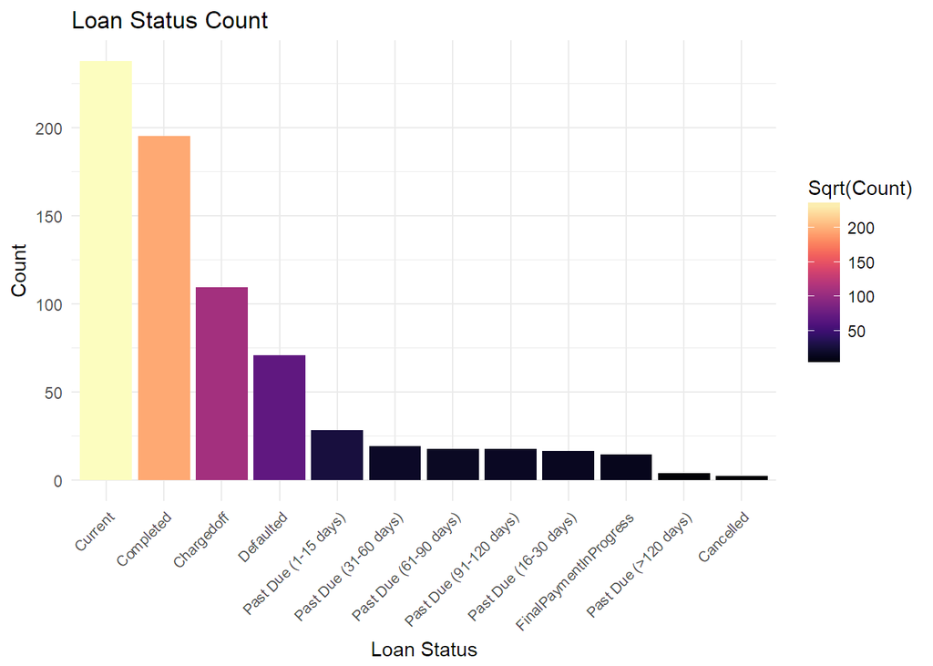

```r
loanstat=RawData$LoanStatus
RawData %>%
  count(LoanStatus) %>%
  mutate(LoanStatus=reorder(LoanStatus,-n))%>%
  #filter(n>quantile(n,0.20))%>%
  ggplot(aes(x=LoanStatus, y = sqrt(n),fill=sqrt(n)))+
    geom_bar(stat = "identity")+
    #coord_trans(x='sqrt')+
    #coord_polar()+
    scale_fill_viridis(option = "A")+
    theme_minimal()+
    theme(axis.text.x = element_text(size =8, angle= 45, hjust=1))+
    labs(title="Loan Status Count ", x="Loan Status", y="Count",fill="Sqrt(Count)")
```

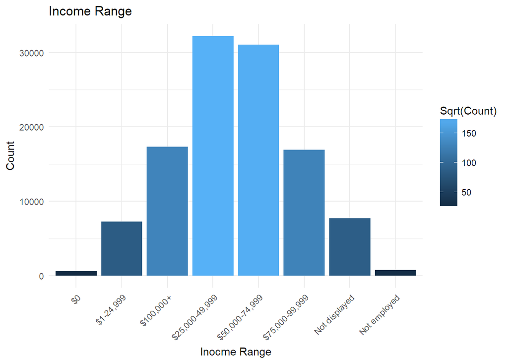

```r
IncomeRange=RawData$IncomeRange
RawData %>%
  count(IncomeRange) %>%
  #mutate(IncomeRange=reorder(IncomeRange,-n))%>%
  #filter(n>quantile(n,0.20))%>%
  ggplot(aes(x=IncomeRange, y = n,fill=sqrt(n)))+
    geom_bar(stat = "identity")+
    #coord_trans(x='log')+
    #coord_polar()+
    #scale_fill_viridis(option = "A")+
    theme_minimal()+
    theme(axis.text.x = element_text(size = , angle= 45, hjust=1))+
    labs(title="Income Range", x="Inocme Range", y="Count",fill="Sqrt(Count)")
```

BorrowerRate

The Borrower’s interest rate for this loan.

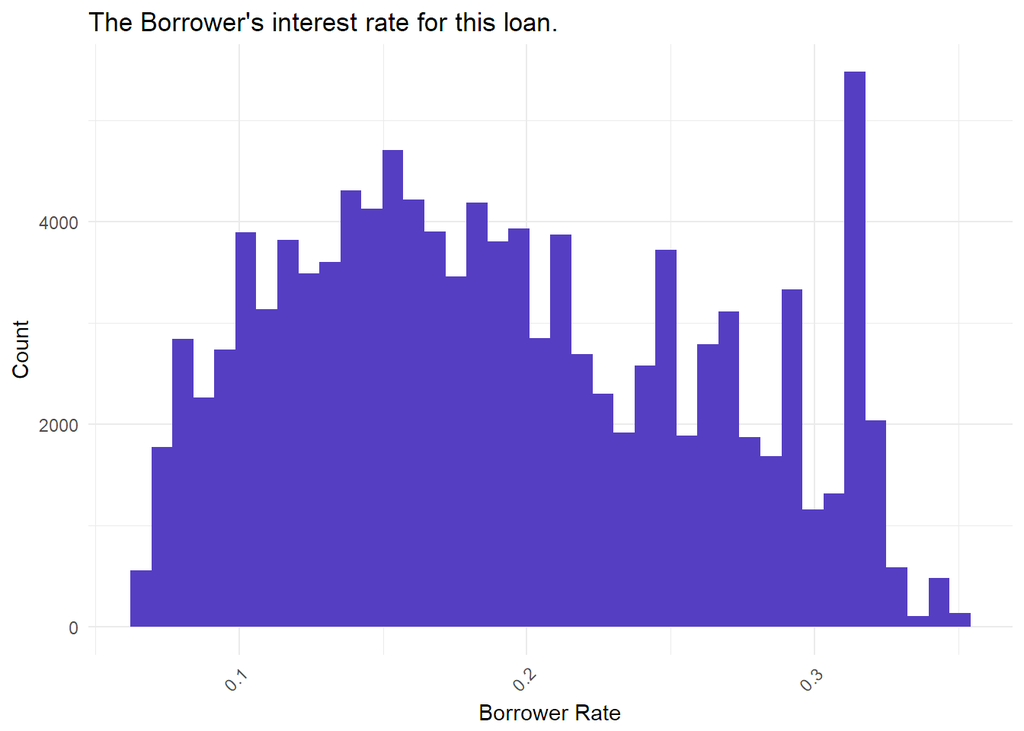

```r
BorrowerRate=RawData$BorrowerRate
RawData%>%
  filter(BorrowerRate>quantile(BorrowerRate,0.01))%>%
  filter(BorrowerRate<quantile(BorrowerRate,0.99))%>%
  #count(BorrowerRate)%>%
  ggplot(aes(x=BorrowerRate))+
    geom_histogram(bins=40,fill="#563ec3")+
    theme_minimal()+
    theme(axis.text.x = element_text(size = , angle= 45, hjust=1))+
    labs(title="The Borrower's interest rate for this loan.  ", x="Borrower Rate", y="Count")
```

Prosper Rating : The Prosper Rating assigned at the time the listing was created between AA - HR. Applicable for loans originated after July 2009.

```r
levels(RawData$ProsperRating..Alpha.)
```

```
## [1] ""   "A"  "AA" "B"  "C"  "D"  "E"  "HR"
```

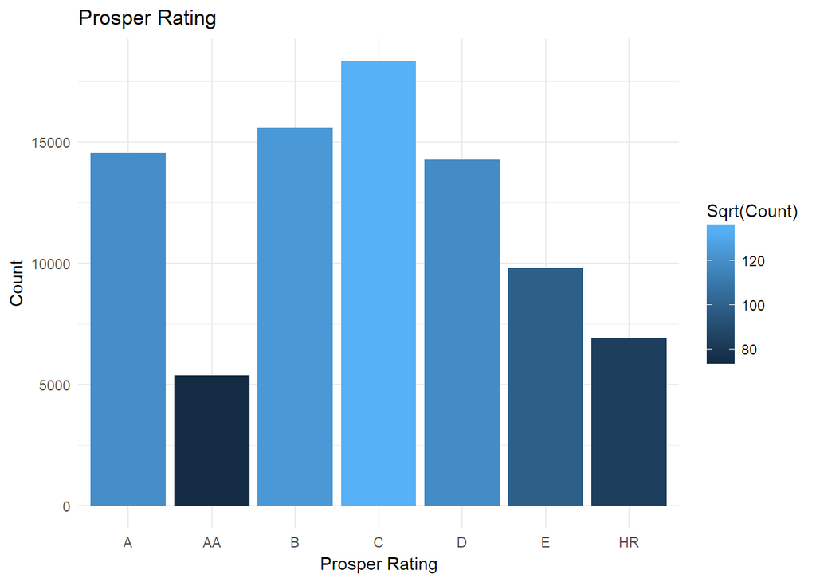

```r
RawData %>%
  filter(RawData$ProsperRating..Alpha.!="")%>%
  #filter(RawData$ListingCreationDate>2009)
  count(ProsperRating..Alpha.) %>%
  #mutate(IncomeRange=reorder(IncomeRange,-n))%>%
  #filter(n>quantile(n,0.20))%>%
  ggplot(aes(x=ProsperRating..Alpha., y = n,fill=sqrt(n)))+
    geom_bar(stat = "identity")+
    theme_minimal()+
    theme(axis.text.x = element_text( ))+
    labs(title="Prosper Rating", x="Prosper Rating", y="Count",fill="Sqrt(Count)")
```

Monthly Loan Payment

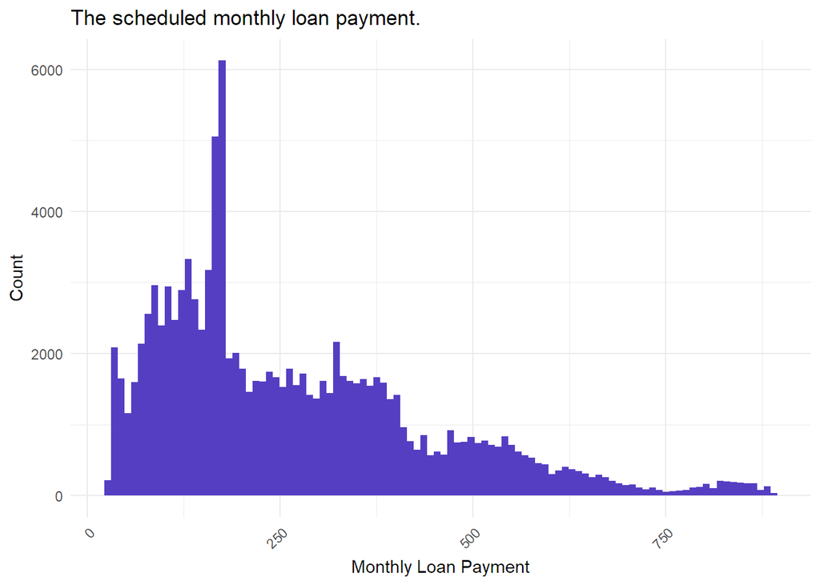

```r
MonthlyLoanPayment=RawData$MonthlyLoanPayment

RawData%>%
  filter(MonthlyLoanPayment>quantile(MonthlyLoanPayment,0.01))%>%
  filter(MonthlyLoanPayment<quantile(MonthlyLoanPayment,0.99))%>%
  ggplot(aes(x=MonthlyLoanPayment))+
    geom_histogram(bins=100,fill="#563ec3")+
    theme_minimal()+
    theme(axis.text.x = element_text(size = , angle= 45, hjust=1))+
    labs(title="The scheduled monthly loan payment.", x="Monthly Loan Payment", y="Count")
```

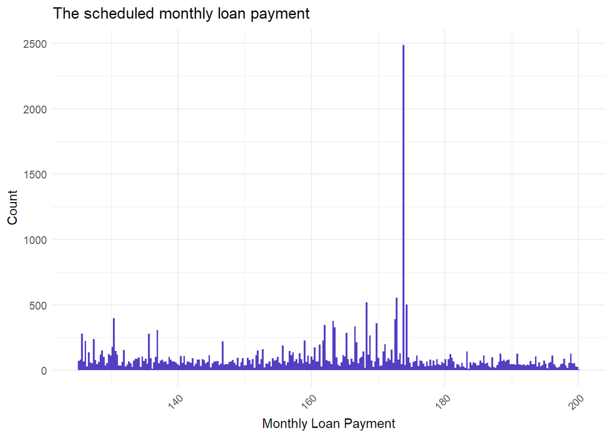

```r
RawData%>%
  filter(MonthlyLoanPayment>125)%>%
  filter(MonthlyLoanPayment<200)%>%
  ggplot(aes(x=MonthlyLoanPayment))+
    geom_histogram(bins=300,fill="#563ec3")+
    theme_minimal()+
    theme(axis.text.x = element_text(size = , angle= 45, hjust=1))+
    labs(title="The scheduled monthly loan payment", x="Monthly Loan Payment", y="Count")
```

LP InterestandFees

Pre charge-off cumulative interest and fees paid by the borrower. If the loan has charged off, this value will exclude any recoveries.

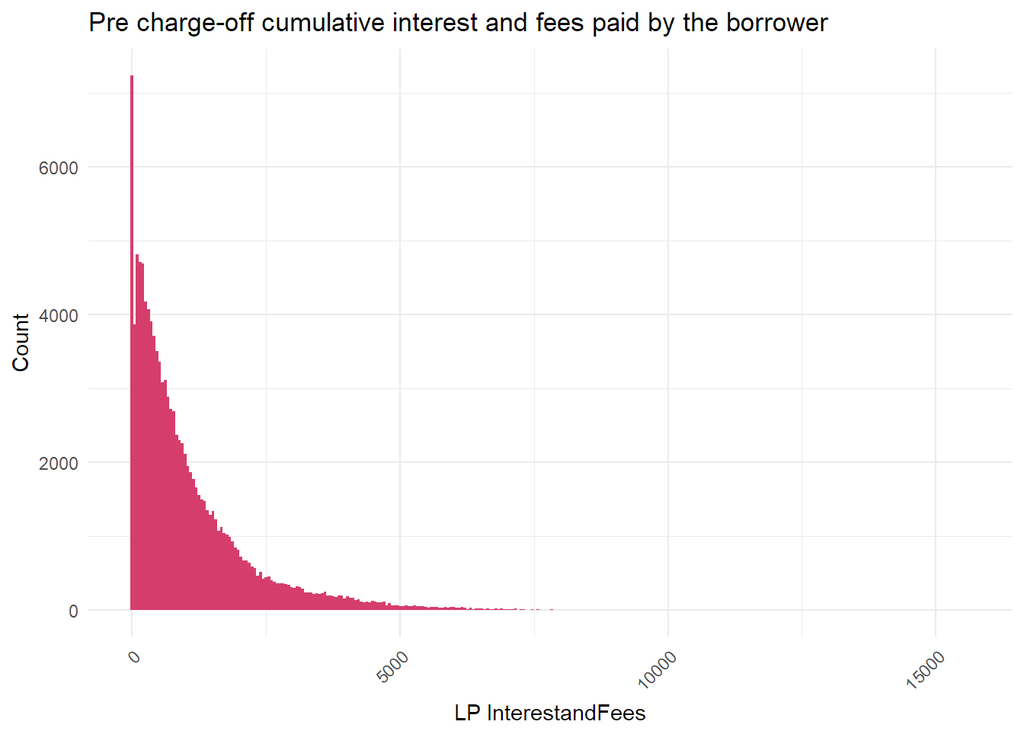

```r
RawData%>%
  #filter(LP_InterestandFees>quantile(MonthlyLoanPayment,0.001))%>%
  #filter(LP_InterestandFees<quantile(MonthlyLoanPayment,0.999))%>%
  ggplot(aes(x=LP_InterestandFees))+
    geom_histogram(bins=300,fill="#d53e6c")+
    theme_minimal()+
    theme(axis.text.x = element_text(size = , angle= 45, hjust=1))+
    labs(title="Pre charge-off cumulative interest and fees paid by the borrower", x="LP InterestandFees", y="Count")
```

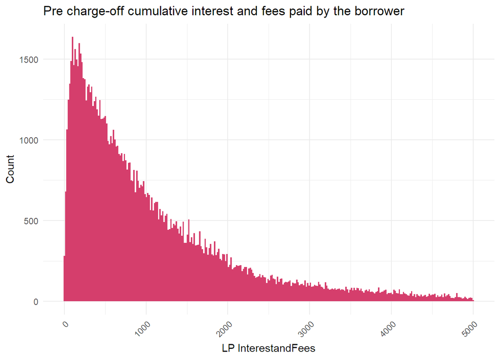

```r
RawData%>%
  filter(LP_InterestandFees>quantile(MonthlyLoanPayment,0.001))%>%
  filter(LP_InterestandFees<5000)%>%
  #filter(LP_InterestandFees<quantile(MonthlyLoanPayment,0.999))%>%
  ggplot(aes(x=LP_InterestandFees))+
    geom_histogram(bins=300,fill="#d53e6c")+
    theme_minimal()+
    theme(axis.text.x = element_text(size = , angle= 45, hjust=1))+
    labs(title="Pre charge-off cumulative interest and fees paid by the borrower", x="LP InterestandFees", y="Count")
```

Investors The number of investors that funded the loan.

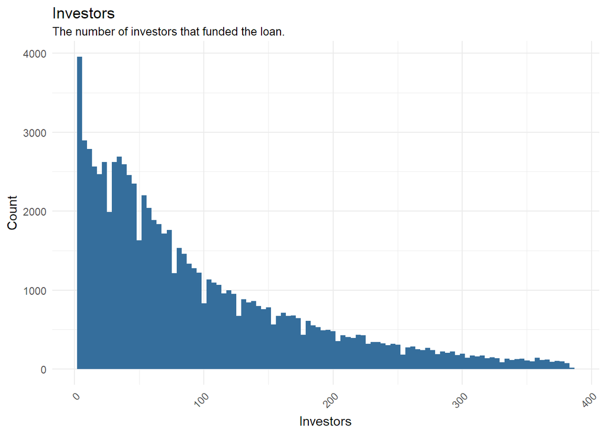

```r
Investors=RawData$Investors

RawData%>%
  filter(Investors>quantile(Investors,0.03))%>%
  #filter(Investors<600)%>%
  filter(Investors<quantile(Investors,0.97))%>%
  ggplot(aes(x=Investors))+
    geom_histogram(bins=100,fill="#356e9c")+
    theme_minimal()+
    theme(axis.text.x = element_text(size = , angle= 45, hjust=1))+
    labs(title="Investors",
         subtitle="The number of investors that funded the loan.",
         x="Investors",
         y="Count")
```

Employment Status Duration The length in months of the employment status at the time the listing was created.

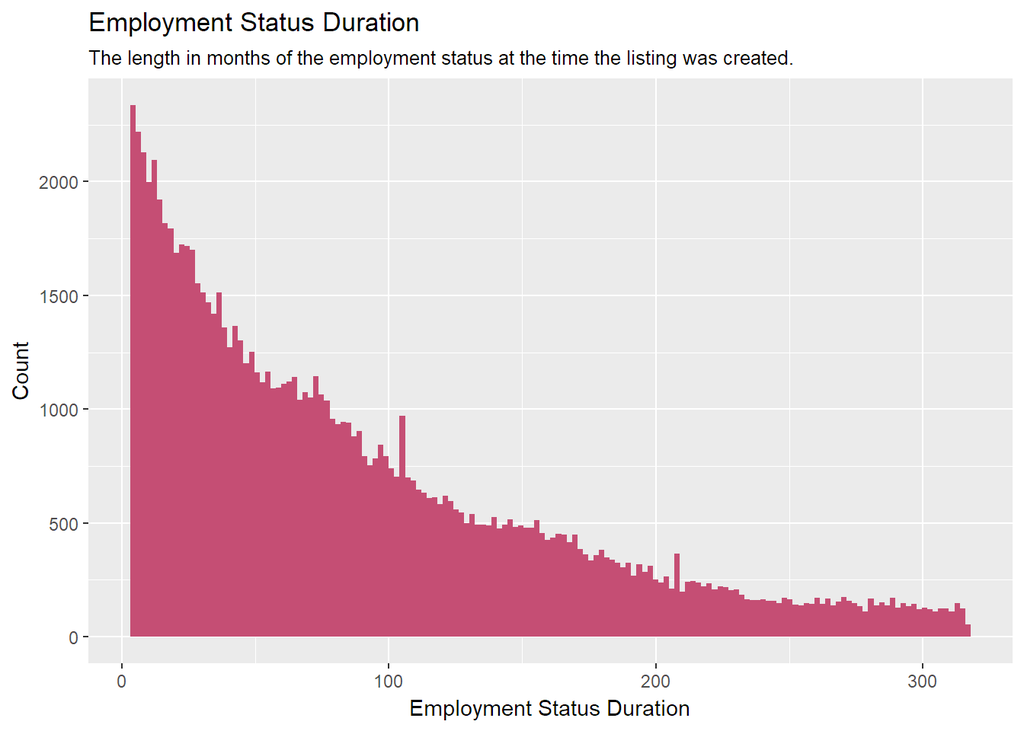

```r
EmploymentStatusDuration=RawData$EmploymentStatusDuration
RawData%>%
  filter(is.finite(EmploymentStatusDuration))%>%
  filter(EmploymentStatusDuration>quantile(EmploymentStatusDuration,0.04))%>%
  filter(EmploymentStatusDuration<quantile(EmploymentStatusDuration,0.96))%>%
  ggplot(aes(EmploymentStatusDuration))+
  geom_histogram(bins=156,fill="#c54e74")+
  labs(title="Employment Status Duration",
         subtitle="The length in months of the employment status at the time the listing was created.",
         x="Employment Status Duration",
         y="Count")
```